# LBB8

Yvonne Lam

10/16/2019

# Report

Classification models were used to predict the risk status of a bank loan.

**Objective**:  
To predict the risk status of a bank loan.

## Analysis

### Data Prep

Data is first read and checked for missing values. Since data is complete and clean, data preparation is done.

```r
library(dplyr)
library(caret)
library(class)
library(skimr)
```

```r
library(ggplot2)
library(partykit)
#read data
loan <- read.csv("data_input/loan.csv")
str(loan)
```

```
## 'data.frame':    1000 obs. of  17 variables:
##  $ checking_balance    : Factor w/ 4 levels "< 0 DM","> 200 DM",..: 1 3 4 1 1 4 4 3 4 3 ...
##  $ months_loan_duration: int  6 48 12 42 24 36 24 36 12 30 ...
##  $ credit_history      : Factor w/ 5 levels "critical","good",..: 1 2 1 2 4 2 2 2 2 1 ...
##  $ purpose             : Factor w/ 6 levels "business","car",..: 5 5 4 5 2 4 5 2 5 2 ...
##  $ amount              : int  1169 5951 2096 7882 4870 9055 2835 6948 3059 5234 ...
##  $ savings_balance     : Factor w/ 5 levels "< 100 DM","> 1000 DM",..: 5 1 1 1 1 5 4 1 2 1 ...
##  $ employment_duration : Factor w/ 5 levels "< 1 year","> 7 years",..: 2 3 4 4 3 3 2 3 4 5 ...
##  $ percent_of_income   : int  4 2 2 2 3 2 3 2 2 4 ...
##  $ years_at_residence  : int  4 2 3 4 4 4 4 2 4 2 ...
##  $ age                 : int  67 22 49 45 53 35 53 35 61 28 ...
##  $ other_credit        : Factor w/ 3 levels "bank","none",..: 2 2 2 2 2 2 2 2 2 2 ...
##  $ housing             : Factor w/ 3 levels "other","own",..: 2 2 2 1 1 1 2 3 2 2 ...
##  $ existing_loans_count: int  2 1 1 1 2 1 1 1 1 2 ...
##  $ job                 : Factor w/ 4 levels "management","skilled",..: 2 2 4 2 2 4 2 1 4 1 ...
##  $ dependents          : int  1 1 2 2 2 2 1 1 1 1 ...
##  $ phone               : Factor w/ 2 levels "no","yes": 2 1 1 1 1 2 1 2 1 1 ...
##  $ default             : Factor w/ 2 levels "no","yes": 1 2 1 1 2 1 1 1 1 2 ...
```

```r
#check for missing values
skim(loan)
```

```
## Skim summary statistics
##  n obs: 1000
##  n variables: 17
##
## -- Variable type:factor --------------------------------------------------------
##             variable missing complete    n n_unique
##     checking_balance       0     1000 1000        4
##       credit_history       0     1000 1000        5
##              default       0     1000 1000        2
##  employment_duration       0     1000 1000        5
##              housing       0     1000 1000        3
##                  job       0     1000 1000        4
##         other_credit       0     1000 1000        3
##                phone       0     1000 1000        2
##              purpose       0     1000 1000        6
##      savings_balance       0     1000 1000        5
##                              top_counts ordered
##   unk: 394, < 0: 274, 1 -: 269, > 2: 63   FALSE
##    goo: 530, cri: 293, poo: 88, ver: 49   FALSE
##                no: 700, yes: 300, NA: 0   FALSE
##  1 -: 339, > 7: 253, 4 -: 174, < 1: 172   FALSE
##     own: 713, ren: 179, oth: 108, NA: 0   FALSE
##   ski: 630, uns: 200, man: 148, une: 22   FALSE
##      non: 814, ban: 139, sto: 47, NA: 0   FALSE
##                no: 596, yes: 404, NA: 0   FALSE
##    fur: 473, car: 337, bus: 97, edu: 59   FALSE
##   < 1: 603, unk: 183, 100: 103, 500: 63   FALSE
##
## -- Variable type:integer -------------------------------------------------------
##              variable missing complete    n    mean      sd  p0    p25
##                   age       0     1000 1000   35.55   11.38  19   27
##                amount       0     1000 1000 3271.26 2822.74 250 1365.5
##            dependents       0     1000 1000    1.16    0.36   1    1
##  existing_loans_count       0     1000 1000    1.41    0.58   1    1
##  months_loan_duration       0     1000 1000   20.9    12.06   4   12
##     percent_of_income       0     1000 1000    2.97    1.12   1    2
##    years_at_residence       0     1000 1000    2.85    1.1    1    2
##     p50     p75  p100     hist
##    33     42       75 ▇▇▆▃▂▁▁▁
##  2319.5 3972.25 18424 ▇▃▂▁▁▁▁▁
##     1      1        2 ▇▁▁▁▁▁▁▂
##     1      2        4 ▇▁▅▁▁▁▁▁
##    18     24       72 ▇▅▅▃▁▁▁▁
##     3      4        4 ▂▁▃▁▁▂▁▇
##     3      4        4 ▂▁▆▁▁▃▁▇
```

### Exploratory Data Analysis

EDA was carried out to understand the data better and pick out variables which are good at classifying the target variable(default).

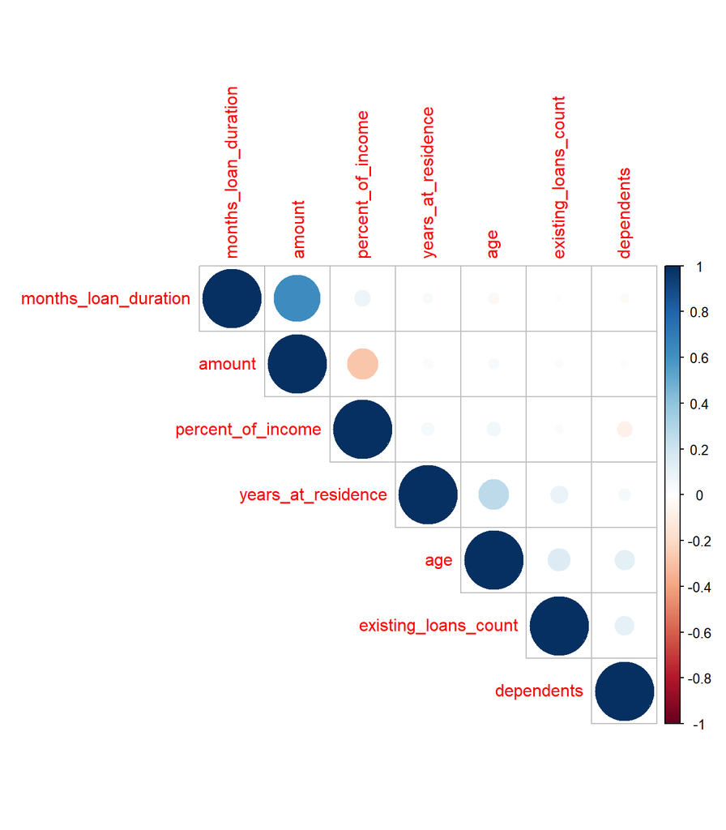

```r
#correlations of numeric variables
library(corrplot)
loan_num <- loan %>% select_if(is.numeric)
corrplot(cor(loan_num), type="upper")
```

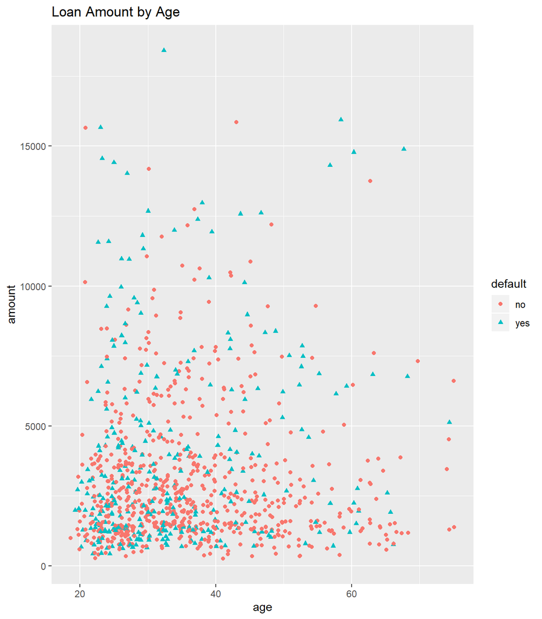

```r
ggplot(loan)+
  geom_jitter(aes(x=age,y=amount, shape=default, colour=default))+
  labs(title = "Loan Amount by Age")
```

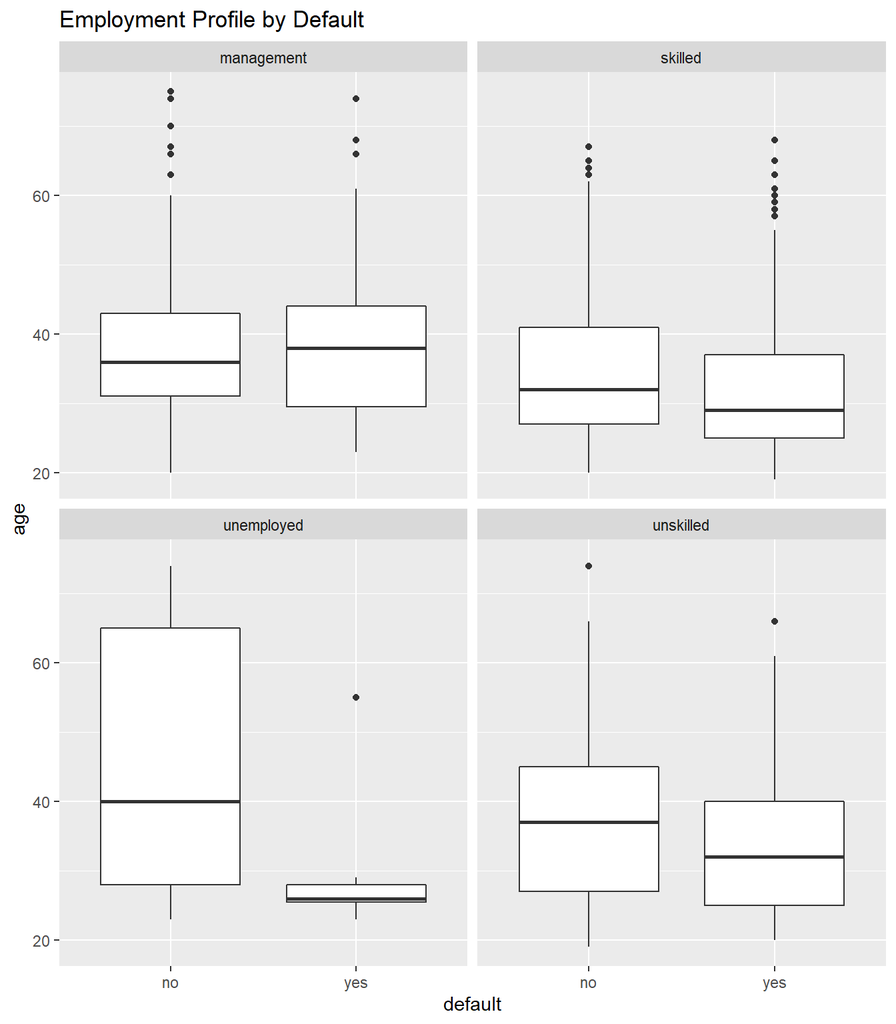

```r
#younger aged tend to borrow more

ggplot(data = loan, aes(x=default, y=age))+
  geom_boxplot()+
  facet_wrap(~job)+
  labs(title = "Employment Profile by Default")
```

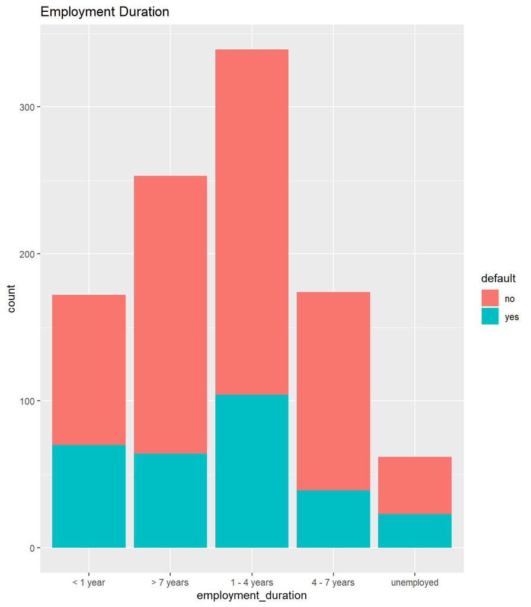

```r
#unemployed default much less

p1 <- ggplot(loan, aes(fill=default))+
  geom_bar(aes(x=credit_history))+
  labs(title = "Credit History")

p2 <- ggplot(loan)+
  geom_bar(aes(x=months_loan_duration, fill=default))+
  labs(title="Loan Duration")

p3 <- ggplot(loan)+
  geom_bar(aes(x=purpose, fill=default))+
  labs(title="Loan Purpose")+
  theme(axis.text.x=element_text(angle=45, hjust=1))

p4 <- ggplot(loan, aes(x=phone, fill=default))+
  geom_bar()+
  labs(title="Contactable by Phone")

p5 <- ggplot(loan, aes(x=other_credit, fill=default))+
  geom_bar()+
  labs(title="Other credit plans")

p6 <- ggplot(loan, aes(x=housing, fill=default))+
  geom_bar()+
  labs(title="Housing")

ggplot(loan)+
  geom_bar(aes(x=employment_duration, fill=default))+
  labs(title="Employment Duration")
```

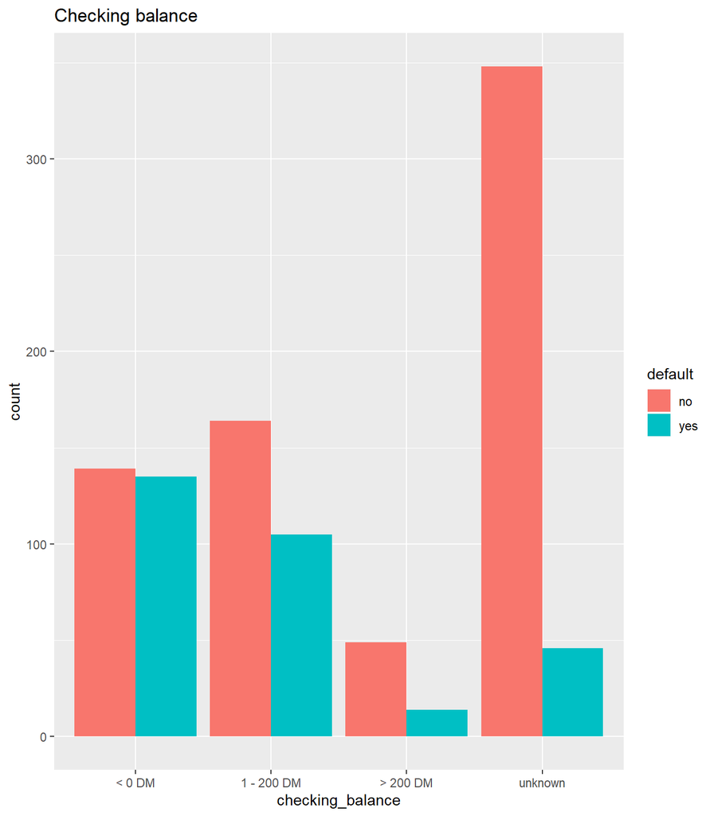

```r
loan$checking_balance <- factor(loan$checking_balance,
                                levels=c("< 0 DM", "1 - 200 DM", "> 200 DM", "unknown"))
ggplot(loan)+
  geom_bar(aes(x=checking_balance, fill=default), position = "dodge")+
  labs(title="Checking balance")
```

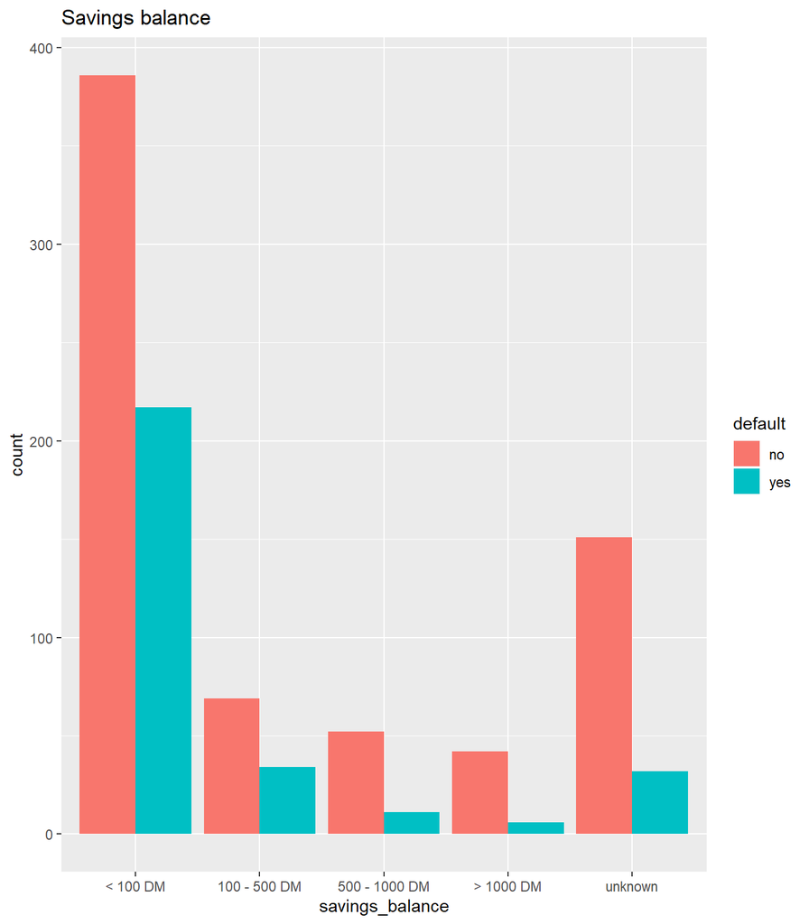

```r
loan$savings_balance <- factor(loan$savings_balance,
                               levels = c("< 100 DM", "100 - 500 DM", "500 - 1000 DM", "> 1000 DM", "unknown"))
ggplot(loan)+
  geom_bar(aes(x=savings_balance, fill=default), position = "dodge")+
  labs(title="Savings balance")
```

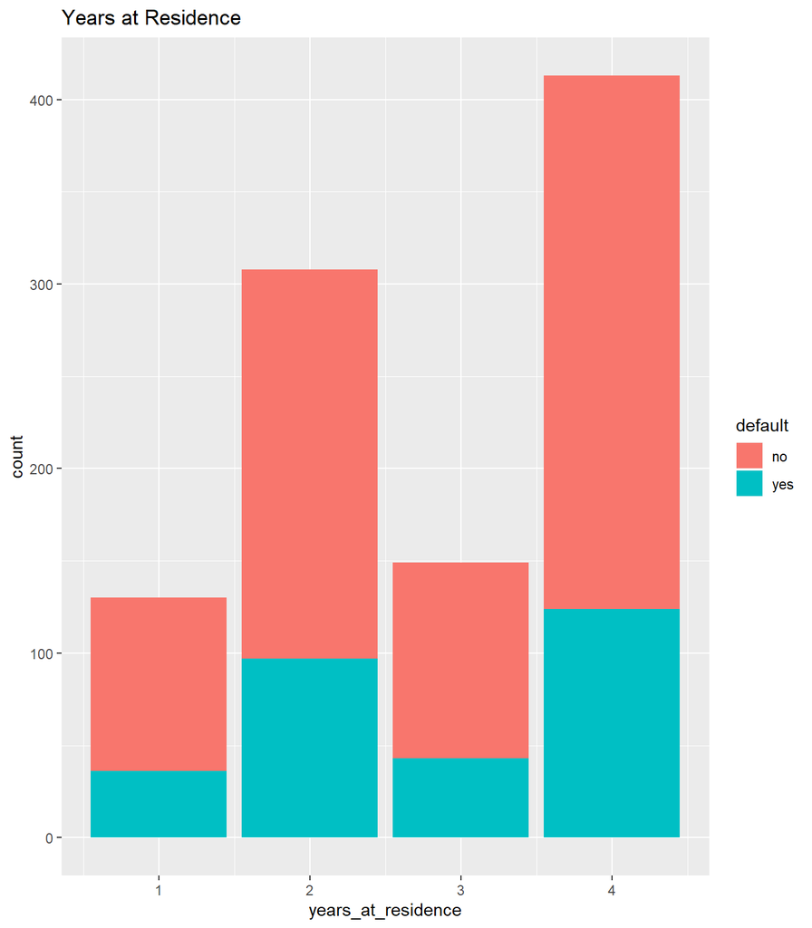

```r
#proportion of defaulters significantly reduce when both saving and checking balance are high

ggplot(loan)+
  geom_bar(aes(x=years_at_residence, fill=default))+
  labs(title="Years at Residence")
```

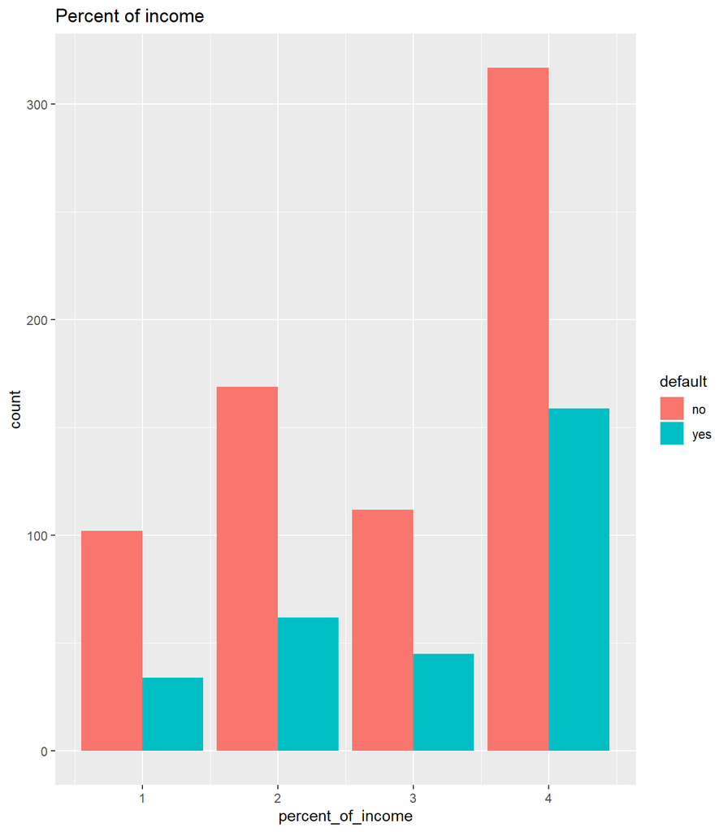

```r
ggplot(loan)+
  geom_bar(aes(x=percent_of_income, fill=default), position = "dodge")+
  labs(title="Percent of income")
```

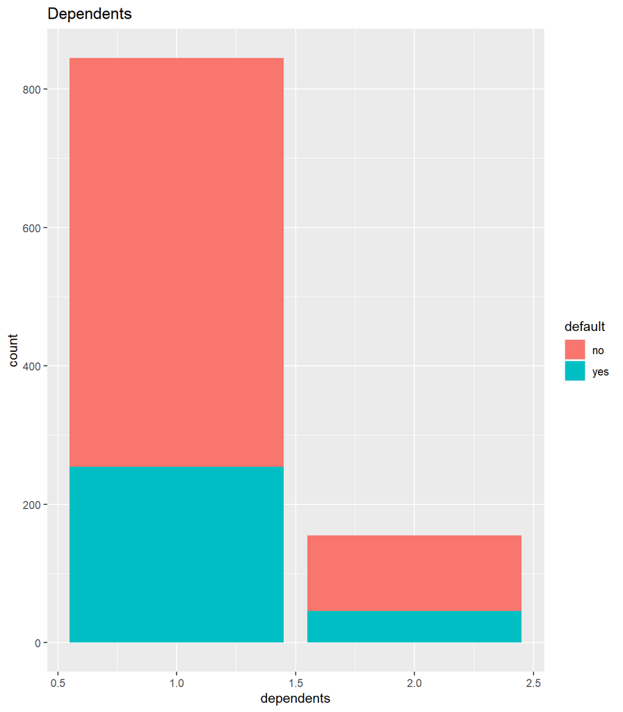

```r
ggplot(loan)+
  geom_bar(aes(x=dependents, fill=default))+
  labs(title="Dependents")
```

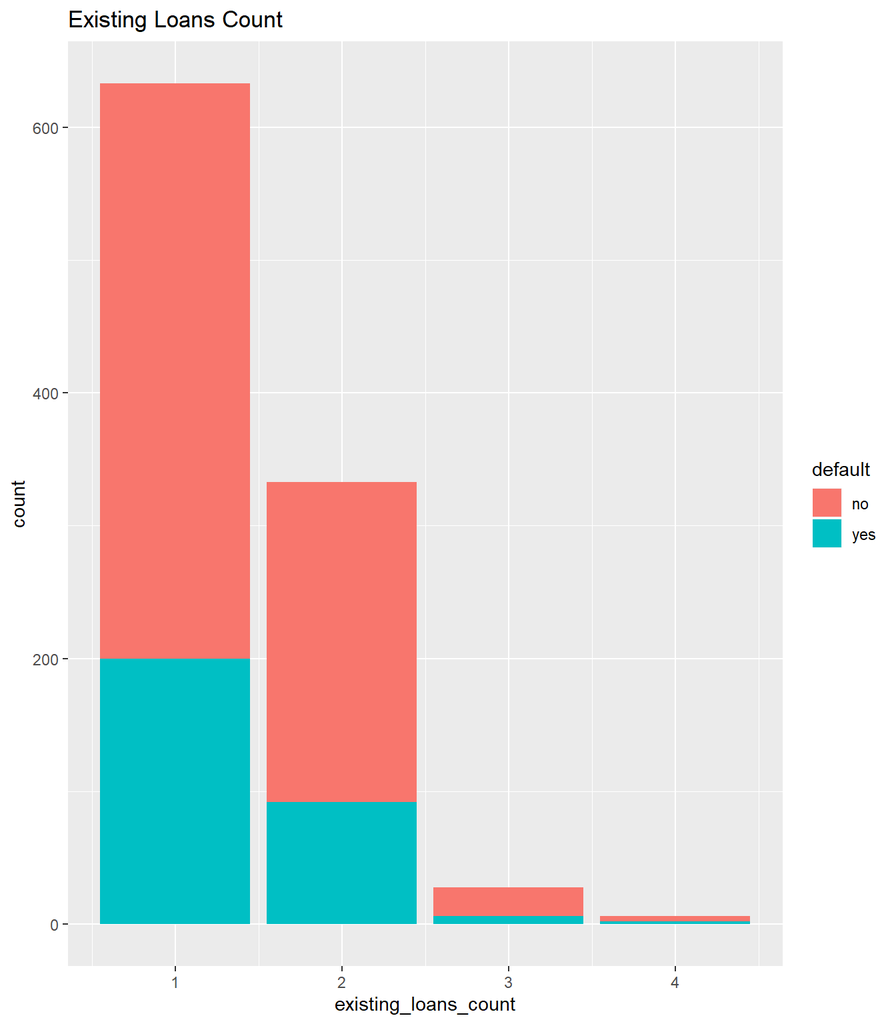

```r
ggplot(loan)+
  geom_bar(aes(x=existing_loans_count, fill=default))+
  labs(title="Existing Loans Count")
```

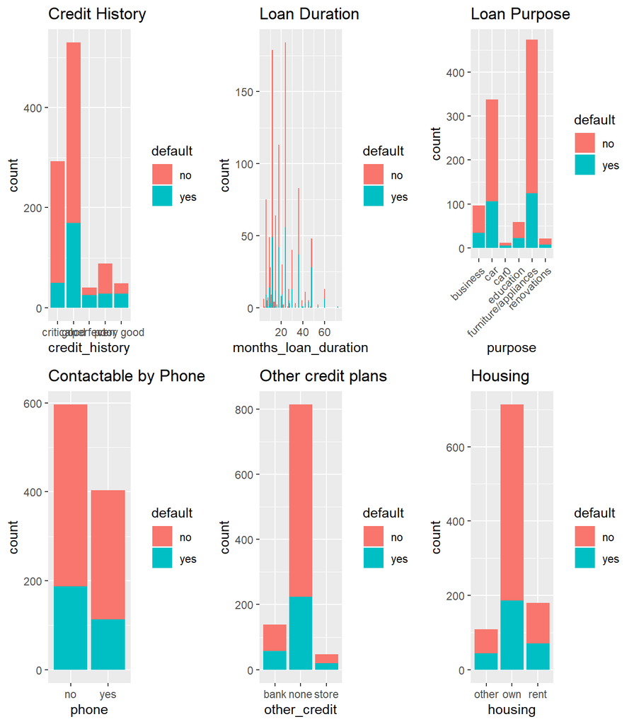

```r
cowplot::plot_grid(p1,p2,p3,p4,p5,p6)
```

Feature engineering

```r
loan <- loan %>%
  mutate(high_balance = ifelse(checking_balance != "< 0 DM" & savings_balance != "< 100 DM", 2, 1)) %>%
  mutate()
```

### Model Fitting

2 algorithms are used to build models for classifying the loan defaults. The dataset is split into train and test set for cross-validation purposes.

```r
#baseline accuracy
acc_base <- round(700/1000,3)
paste("Baseline Accuracy: ", acc_base, "%")
```

```
## [1] "Baseline Accuracy:  0.7 %"
```

```r
#Split train and test sets
set.seed(101)
split <- sample(nrow(loan), nrow(loan)*0.8)
train <- loan[split,]
test <- loan[-split,]

colnames(loan)
```

```
##  [1] "checking_balance"     "months_loan_duration" "credit_history"
##  [4] "purpose"              "amount"               "savings_balance"
##  [7] "employment_duration"  "percent_of_income"    "years_at_residence"
## [10] "age"                  "other_credit"         "housing"
## [13] "existing_loans_count" "job"                  "dependents"
## [16] "phone"                "default"              "high_balance"
```

```r
train_labels <- loan[split,17]
test_labels <- loan[-split,17]

#check train and test sets
dim(loan)
```

```
## [1] 1000   18
```

```r
dim(train)
```

```
## [1] 800  18
```

```r
dim(test)
```

```
## [1] 200  18
```

```r
#check proportion of target variable
prop.table(table(train$default))
```

```
##
##   no  yes
## 0.71 0.29
```

[figure not shown]

```r
#using decision tree
#no modifications
library(partykit)
loan_tree <- ctree(default ~ ., loan, control=ctree_control(maxdepth = 5, mincriterion = 0.95))
plot(loan_tree)
```

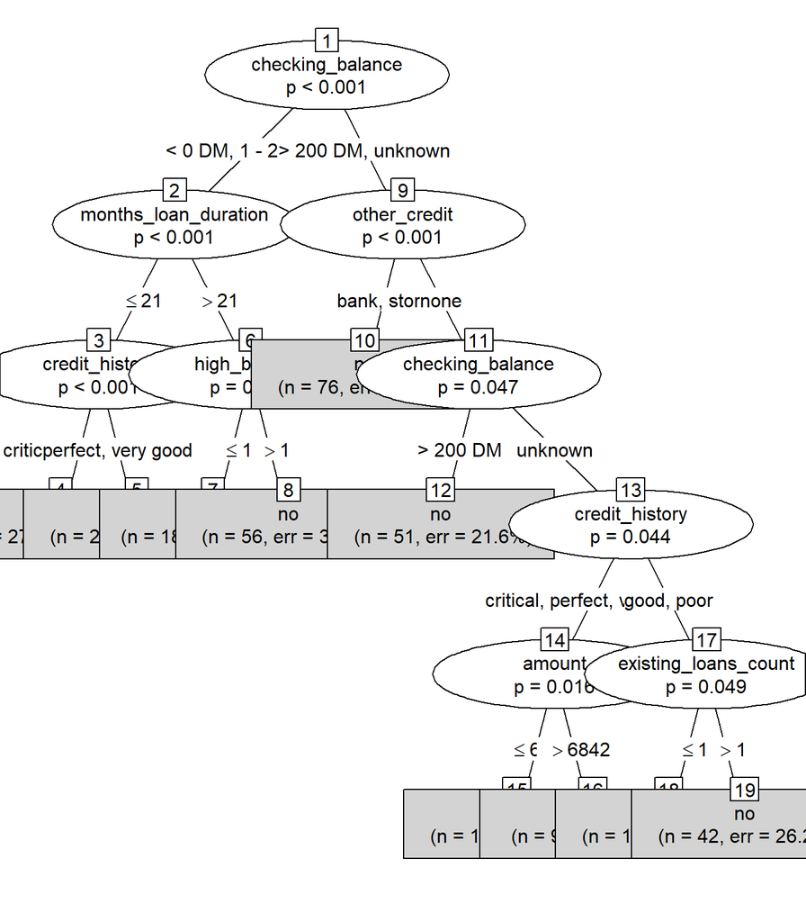

```r
plot(loan_tree, type="simple")
```

```r
#prediction
pred_tree <- predict(loan_tree, test[,-17])
data.frame(pred_tree,test[,17])
```

```
##     pred_tree test...17.
## 8         yes         no
## 10        yes        yes
## 12        yes        yes
## 16        yes        yes
## 29         no         no
## 32        yes         no
## 35         no         no
## 42         no         no
## 44        yes         no
## 47         no         no
## 48         no         no
## 54         no         no
## 56         no         no
## 59         no         no
```

[output cut: 186 more lines]

```r
#confusion matrix
confusionMatrix(pred_tree,test[,17])
```

```
## Confusion Matrix and Statistics
##
##           Reference
## Prediction  no yes
##        no  116  35
##        yes  16  33
##
##                Accuracy : 0.745
##                  95% CI : (0.6787, 0.8039)
##     No Information Rate : 0.66
##     P-Value [Acc > NIR] : 0.006008
##
##                   Kappa : 0.3905
##
##  Mcnemar's Test P-Value : 0.011719
##
##             Sensitivity : 0.8788
##             Specificity : 0.4853
##          Pos Pred Value : 0.7682
##          Neg Pred Value : 0.6735
##              Prevalence : 0.6600
##          Detection Rate : 0.5800
##    Detection Prevalence : 0.7550
##       Balanced Accuracy : 0.6820
##
##        'Positive' Class : no
##
```

```r
tree_acc <- round((116+33)/200,3)
tree_sens <- round(116/(116+16),3)
tree_spec <- round(33/(33+35),3)
tree_prec <- round(116/(116+35),3)
tree_vals <- c(tree_acc, tree_sens, tree_spec, tree_prec)
```

```r
#using random forest
library(randomForest)
set.seed(200)
ctrl <- trainControl(method = "repeatedcv", number = 5, repeats = 3)
loan_rf <- train(default ~., data=train, method = "rf", trControl = ctrl, importance=T)
loan_rf$finalModel
```

```
##
## Call:
##  randomForest(x = x, y = y, mtry = param$mtry, importance = ..1)
##                Type of random forest: classification
##                      Number of trees: 500
## No. of variables tried at each split: 19
##
##         OOB estimate of  error rate: 26.25%
## Confusion matrix:
##      no yes class.error
## no  495  73   0.1285211
## yes 137  95   0.5905172
```

```r
varImp(loan_rf)
```

```
## rf variable importance
##
##   only 20 most important variables shown (out of 36)
##
##                               Importance
## checking_balanceunknown           100.00
## months_loan_duration               72.79
## savings_balanceunknown             44.18
## employment_durationunemployed      41.58
## credit_historyvery good            41.47
## amount                             40.48
## credit_historyperfect              39.20
## high_balance                       34.15
## other_creditnone                   32.68
## age                                26.14
## percent_of_income                  23.23
## other_creditstore                  20.01
## employment_duration> 7 years       19.90
## checking_balance1 - 200 DM         18.24
## savings_balance> 1000 DM           17.35
## phoneyes                           16.98
## years_at_residence                 16.85
## existing_loans_count               16.64
## purposecar                         16.52
## credit_historygood                 16.02
```

```r
#prediction
pred_rf <- predict(loan_rf, test)

#confusion matrix
confusionMatrix(pred_rf,test_labels)
```

```
## Confusion Matrix and Statistics
##
##           Reference
## Prediction  no yes
##        no  113  35
##        yes  19  33
##
##                Accuracy : 0.73
##                  95% CI : (0.6628, 0.7902)
##     No Information Rate : 0.66
##     P-Value [Acc > NIR] : 0.02049
##
##                   Kappa : 0.362
##
##  Mcnemar's Test P-Value : 0.04123
##
##             Sensitivity : 0.8561
##             Specificity : 0.4853
##          Pos Pred Value : 0.7635
##          Neg Pred Value : 0.6346
##              Prevalence : 0.6600
##          Detection Rate : 0.5650
##    Detection Prevalence : 0.7400
##       Balanced Accuracy : 0.6707
##
##        'Positive' Class : no
##
```

```r
rf_acc <- round((113+33)/200,3)
rf_sens <- round(113/(113+19),3)
rf_spec <- round(33/(33+35),3)
rf_prec <- round(113/(113+35),3)
rf_vals <- c(rf_acc, rf_sens, rf_spec, rf_prec)
```

### Compare models

```r
data.frame(row.names = c("Accuracy", "Sensitivity", "Specificity", "Precision"), cbind(tree_vals,rf_vals))
```

```
##             tree_vals rf_vals
## Accuracy        0.745   0.730
## Sensitivity     0.879   0.856
## Specificity     0.485   0.485
## Precision       0.768   0.764
```

## LBB Task

Use any of the 3 classification algorithms you’ve learned to predict the risk status of a bank loan. The variable default in the dataset indicates whether the applicant did default on the loan issued by the bank. Start by reading the `loan.csv` dataset in, a dataset that is originally from Professor Dr. Hans Hofmann. (Refer to our RMD for the explanation of each predictors)

Use an R Markdown document to lay out your process, and explain the methodology in 1 or 2 brief paragraph. The student should be awarded the full (3) points when: - The preprocessing steps are done, and the student show an understanding of holding out a test / cross validation set for an estimate of the model’s performance on unseen data - The model’s performance is sufficiently explained (accuracy may **not** be the most helpful metric here! Recall about what you’ve learned regarding specificity and sensitivity) - The student demonstrated extra effort in evaluating his/her model, and proposes ways to improve the accuracy obtained from the initial model

# Summary

The random forest model is not much better than an initial decision tree model. The metric scores were similar. Even though there was an attempt to feature engineer, one feature might not be enough to significantly improve the prediction capability of the model. To improve the accuracy scores obtained from initial models, better and more features should be created after more data analysis is carried out. Also, the model could be fine-tuned as well to optimize the model to given dataset, such as checking the optimum number of trees used and number of variables tried.